# R Notebook

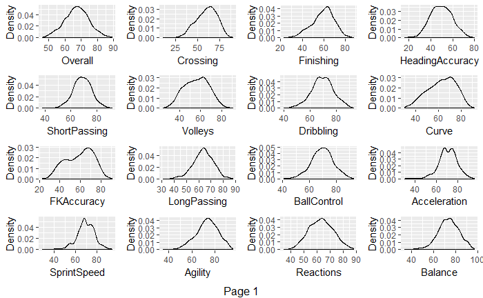

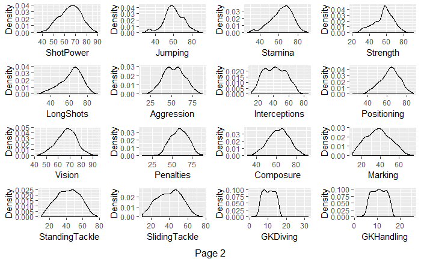

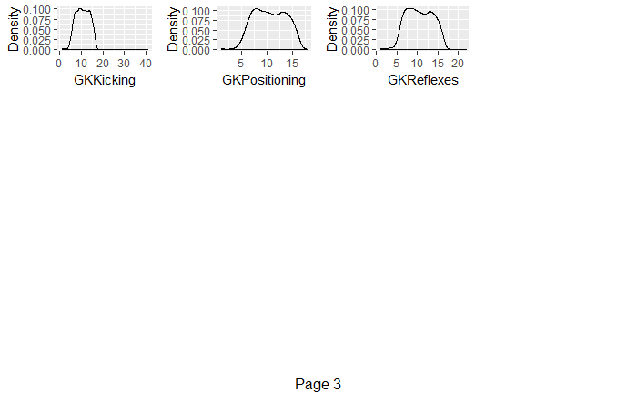

```r
plot_density(df_CAM)
```

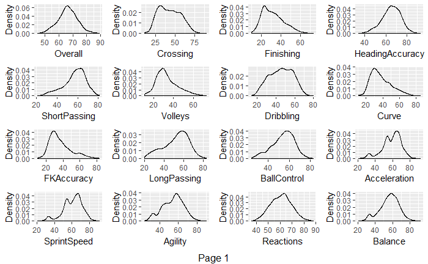

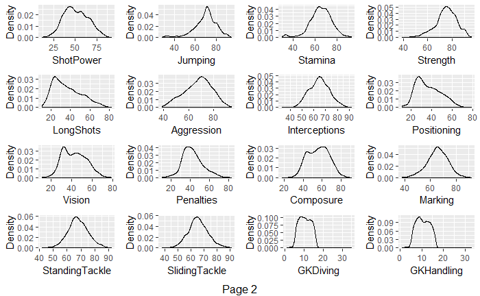

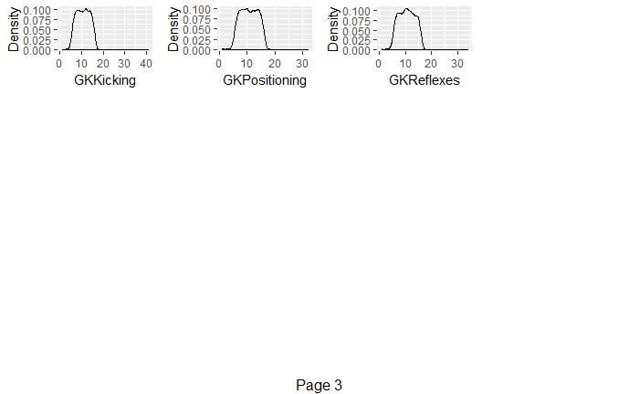

```r
plot_density(df_CB)
```

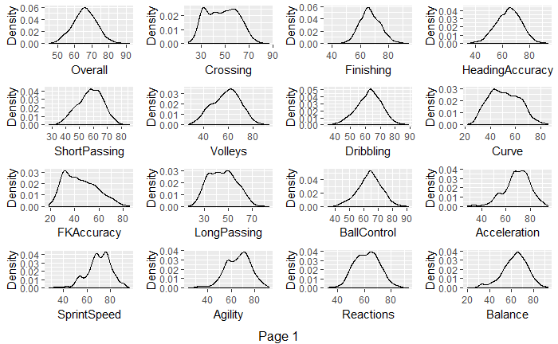

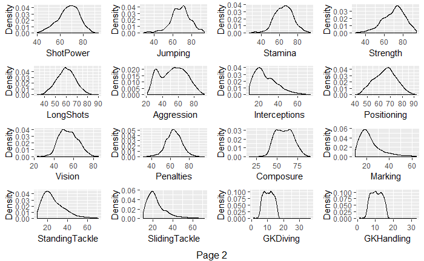

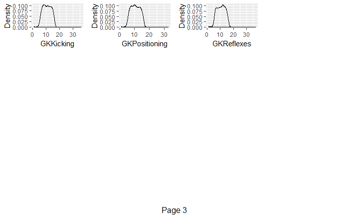

```r
plot_density(df_ST)
```

16. Merge GK,CAM,CB and ST into one dataset.

```r
df_Final= rbind(df_GK,df_CB,df_CAM,df_ST)
df_Final$Best.Position = factor(df_Final$Best.Position,labels=c("GK","CB","CAM","ST"))
```

17. Class percetnage

```r
frequency=round(prop.table(table(df_Final$Best.Position))*100,1)
frequency
```

```
  GK   CB  CAM   ST
19.8 35.6 19.4 25.2
```

18. Balancing classes

```r
library(caret)
######## Using downsample function to downsample the classes to theclass with the lowest proportion------------
df_intermediate=downSample(df_Final,df_Final$Best.Position,list=TRUE)
df_downsample=as.data.frame(df_intermediate)
```

19. Frequency after balancing

```r
####### Proportion of classes after downsampling and balancing of data-------
freq=round(prop.table(table(df_downsample$y))*100,1)
freq
```

```
 GK  CB CAM  ST
 25  25  25  25
```

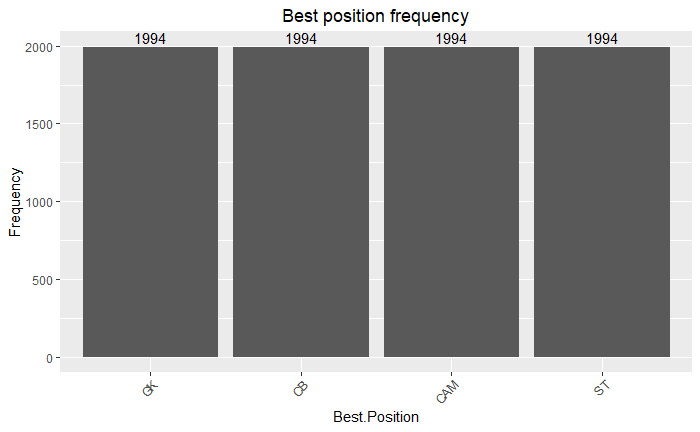

```r
library(forcats)
p <- ggplot(df_downsample, aes(x = forcats::fct_infreq(y))) +
      geom_bar() +theme(axis.text.x=element_text(angle=45,hjust=1))+
      geom_text(stat='count', aes(label=..count..), vjust=-0.3)+labs(title="Best position frequency",
       x = "Best.Position",y="Frequency")
p
```

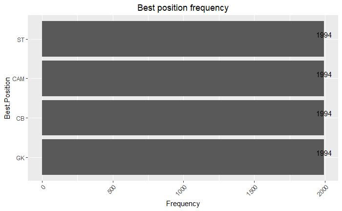

```r
p+coord_flip()
```

20. Altering position of players to discrete variable rather than cateogrical

```r
df_downsample=df_downsample[,-41]
df_downsample$y = factor(df_downsample$y,levels= c('GK','CB','CAM','ST'),
                          labels = c(1,2,3,4))
str(df_downsample)
```

```
'data.frame':   7976 obs. of  41 variables:
 $ x.Name           : Factor w/ 16584 levels " A. Abbas"," A. Abdennour",..: 12067 3240 5226 4007 9972 3357 10038 10467 11746 3808 ...
 $ x.Overall        : int  62 66 66 79 56 64 66 65 68 64 ...
 $ x.Weak.Foot      : Factor w/ 5 levels "1","2","3","4",..: 3 2 4 3 2 3 3 3 3 4 ...
 $ x.Skill.Moves    : Factor w/ 5 levels "1","2","3","4",..: 3 2 3 3 2 3 3 3 2 3 ...
 $ x.Work.Rate      : Factor w/ 9 levels "1","2","3","4",..: 5 6 4 8 5 5 4 5 7 4 ...
 $ x.Body.Type      : Factor w/ 9 levels "1","2","3","4",..: 8 2 5 2 1 5 1 5 2 5 ...
 $ x.Crossing       : int  53 49 51 78 35 50 58 68 66 57 ...
 $ x.Finishing      : int  52 59 62 79 41 55 59 56 69 53 ...
 $ x.HeadingAccuracy: int  50 45 47 68 43 39 51 60 43 33 ...
 $ x.ShortPassing   : int  67 72 66 78 61 65 63 67 67 67 ...
 $ x.Volleys        : int  55 52 59 74 44 59 53 56 63 50 ...
 $ x.Dribbling      : int  63 58 67 77 62 68 68 67 67 70 ...
 $ x.Curve          : int  59 51 63 80 49 66 62 64 66 71 ...
 $ x.FKAccuracy     : int  62 47 35 79 45 58 54 59 65 64 ...
```

[output cut: 27 more lines]

21. Splitting data into train and test

```r
library(caTools)
set.seed(123)
split = sample.split(df_downsample$y, SplitRatio = 0.7)
training_set = subset(df_downsample, split == TRUE)
test_set = subset(df_downsample, split == FALSE)
table(training_set$y)
```

```
   1    2    3    4
1396 1396 1396 1396
```

```r
table(test_set$y)
```

```
  1   2   3   4
598 598 598 598
```

———————————————————————————————————————————————————————————————————————————————————————————————————————————————————————————————————————————————————————————————————————————————————————————————————————————————————————————————————————————————————————————————————————————————————————————————————————————————————————————————————————————————————————————————————————————————————————————————————————————–CLASSIFICATION models————————————————————–

1. CLASSIFICATION MODELSS SVM tuning

```r
####                                              SVM                               #####
##install.packages("e1071")
library(e1071)
######## TRain control-----------
Train_ControlSVM <- trainControl(
  method = "cv",
  number = 10,
  savePredictions = 'final',
  repeats=3,
  classProbs = T,
  search="grid")
```

```
`repeats` has no meaning for this resampling method.
```

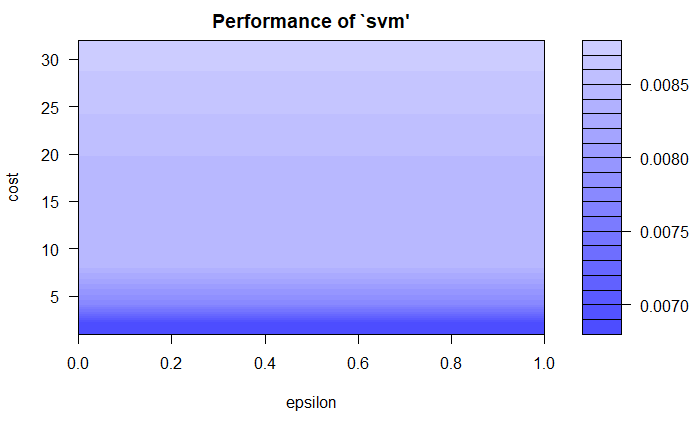

```r
######### Tuned model implemetnation at different model parameter combinations-----------
tuned_model = tune(svm, y~., data = training_set[,c(2,7:41)],
                   ranges = list(epsilon = seq (0, 1, 0.1), cost = 2^(0:5)), kernel='linear',trControl=Train_ControlSVM)
plot (tuned_model)
```

```r
summary (tuned_model)
```

```
Parameter tuning of ‘svm’:

- sampling method: 10-fold cross validation

- best parameters:
 epsilon cost
       0    1

- best performance: 0.006804906

- Detailed performance results:
   epsilon cost       error  dispersion
1      0.0    1 0.006804906 0.002503780
2      0.1    1 0.006804906 0.002503780
3      0.2    1 0.006804906 0.002503780
```

[output cut: 63 more lines]

```r
opt_model = tuned_model$best.model
summary(opt_model)
```

```
Call:
best.tune(method = svm, train.x = y ~ ., data = training_set[, c(2, 7:41)], ranges = list(epsilon = seq(0,
    1, 0.1), cost = 2^(0:5)), kernel = "linear", trControl = Train_ControlSVM)


Parameters:
   SVM-Type:  C-classification
 SVM-Kernel:  linear
       cost:  1
      gamma:  0.02857143

Number of Support Vectors:  199

 ( 85 28 8 78 )


Number of Classes:  4

Levels:
 1 2 3 4
```

2. ACCuracy of training data of trained SVM tuned model

```r
pred1 = predict (opt_model, training_set[,c(2,7:40)])
cm1 = table(Predicted = pred1, Actual = training_set$y)
cm1
```

```
         Actual
Predicted    1    2    3    4
        1 1383    0    0   14
        2    0 1396    0    0
        3    0    0 1396    0
        4   13    0    0 1382
```

```r
sum(diag(cm1))/sum(cm1)
```

```
[1] 0.9951648
```

3. Testing data results for SVM tuned model

```r
pred1_1 = predict (opt_model, test_set[,c(2,7:40)])
cm1_1 = table(Predicted = pred1_1, Actual = test_set$y)
cm1_1
```

```
         Actual
Predicted   1   2   3   4
        1 590   1   0   5
        2   0 597   0   1
        3   0   0 598   0
        4   8   0   0 592
```

```r
sum(diag(cm1_1))/sum(cm1_1)
```

```
[1] 0.9937291
```

```r
confusionMatrix(pred1_1,test_set$y)
```

```
Confusion Matrix and Statistics

          Reference
Prediction   1   2   3   4
         1 590   1   0   5
         2   0 597   0   1
         3   0   0 598   0
         4   8   0   0 592

Overall Statistics

               Accuracy : 0.9937
                 95% CI : (0.9897, 0.9965)
    No Information Rate : 0.25
    P-Value [Acc > NIR] : < 2.2e-16

                  Kappa : 0.9916
 Mcnemar's Test P-Value : NA

Statistics by Class:

                     Class: 1 Class: 2 Class: 3 Class: 4
Sensitivity            0.9866   0.9983     1.00   0.9900
Specificity            0.9967   0.9994     1.00   0.9955
Pos Pred Value         0.9899   0.9983     1.00   0.9867
Neg Pred Value         0.9955   0.9994     1.00   0.9967
Prevalence             0.2500   0.2500     0.25   0.2500
Detection Rate         0.2467   0.2496     0.25   0.2475
Detection Prevalence   0.2492   0.2500     0.25   0.2508
Balanced Accuracy      0.9916   0.9989     1.00   0.9928
```

—————————————————————————————————————————————————————————————————————————————————————————————————————————————————————————————————————————————————————————————————————————————————————————————————————————————————————————————————————————————————————————————————————————————————————————————————————————————————————————————————————————————————————————————————————————————————————————————————————————————————————————————————————————————————————————————————————————————————————————————————————————————————————————————————————————————–RANDOM FOREST————————————————————-

4. random FOREST classification model

```r
###Traincontrol ##cross-validation (cv)
Train_Control <- trainControl(
  method = "cv",
  number = 10,
  savePredictions = 'final',
  repeats=3,
  classProbs = T,
  search="grid")  ####### Search = 'grid' grid search-----------
```

```
`repeats` has no meaning for this resampling method.
```

```r
######## Tunegrid for mtry values from 1 to 20-------
tunegrid<- expand.grid(.mtry=c(1:20))
######### Conveting discreter= variables backt to categorical variables specifically for Random Forest model------
training_RF=training_set
training_RF$y = factor(training_set$y,labels= c('GK','CB','CAM','ST'),
                          levels = c(1,2,3,4))
test_RF=test_set
test_RF$y=factor(test_set$y,labels= c('GK','CB','CAM','ST'),
                          levels = c(1,2,3,4))
#Training the random forest model using grid search for different model parameters------
model_rf<-train(y~., data = training_RF[,c(2,7:41)], method='rf', trControl=Train_Control, tuneGrid=tunegrid)
summary(model_rf)
```

```
                Length Class      Mode
call                4  -none-     call
type                1  -none-     character
predicted        5584  factor     numeric
err.rate         2500  -none-     numeric
confusion          20  -none-     numeric
votes           22336  matrix     numeric
oob.times        5584  -none-     numeric
classes             4  -none-     character
importance         34  -none-     numeric
importanceSD        0  -none-     NULL
localImportance     0  -none-     NULL
proximity           0  -none-     NULL
ntree               1  -none-     numeric
mtry                1  -none-     numeric
forest             14  -none-     list
y                5584  factor     numeric
test                0  -none-     NULL
inbag               0  -none-     NULL
xNames             34  -none-     character
problemType         1  -none-     character
tuneValue           1  data.frame list
obsLevels           4  -none-     character
param               0  -none-     list
```

```r
print(model_rf)
```

```
Random Forest

5584 samples
  35 predictor
   4 classes: 'GK', 'CB', 'CAM', 'ST'

No pre-processing
Resampling: Cross-Validated (10 fold)
Summary of sample sizes: 5024, 5027, 5025, 5027, 5024, 5026, ...
Resampling results across tuning parameters:

  mtry  Accuracy   Kappa
   1    0.9783311  0.9711080
   2    0.9792268  0.9723023
   3    0.9808413  0.9744549
   4    0.9804781  0.9739706
   5    0.9828069  0.9770758
   6    0.9822686  0.9763581
   7    0.9802995  0.9737326
   8    0.9813738  0.9751650
   9    0.9815517  0.9754022
  10    0.9811946  0.9749260
  11    0.9802982  0.9737309
  12    0.9801219  0.9734958
  13    0.9797638  0.9730183
  14    0.9797619  0.9730158
  15    0.9804777  0.9739702
  16    0.9795843  0.9727789
  17    0.9785115  0.9713486
  18    0.9792281  0.9723040
  19    0.9783301  0.9711067
  20    0.9788696  0.9718261

Accuracy was used to select the optimal model using the largest value.
The final value used for the model was mtry = 5.
```

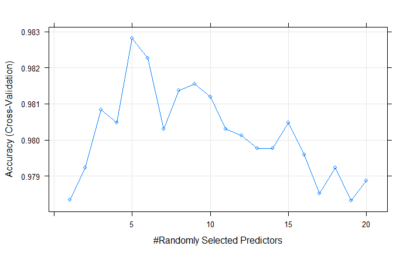

```r
plot(model_rf)
```

```r
###### COnfusion marix for training data using optimum random forest model-----------
pred_rftrain<-predict(object = model_rf, training_RF[,c(2,7:40)])
confusionMatrix(training_RF$y,pred_rftrain)
```

```
Confusion Matrix and Statistics

          Reference
Prediction   GK   CB  CAM   ST
       GK  1396    0    0    0
       CB     0 1396    0    0
       CAM    0    0 1396    0
       ST     0    0    0 1396

Overall Statistics

               Accuracy : 1
                 95% CI : (0.9993, 1)
    No Information Rate : 0.25
    P-Value [Acc > NIR] : < 2.2e-16

                  Kappa : 1
 Mcnemar's Test P-Value : NA

Statistics by Class:

                     Class: GK Class: CB Class: CAM Class: ST
Sensitivity               1.00      1.00       1.00      1.00
Specificity               1.00      1.00       1.00      1.00
Pos Pred Value            1.00      1.00       1.00      1.00
Neg Pred Value            1.00      1.00       1.00      1.00
Prevalence                0.25      0.25       0.25      0.25
Detection Rate            0.25      0.25       0.25      0.25
Detection Prevalence      0.25      0.25       0.25      0.25
Balanced Accuracy         1.00      1.00       1.00      1.00
```

```r
###### COnfusion marix for testing data using optimum random forest model---------
pred_rftest<-predict(object = model_rf, test_RF[,c(2,7:40)])
confusionMatrix(test_RF$y,pred_rftest)
```

```
Confusion Matrix and Statistics

          Reference
Prediction  GK  CB CAM  ST
       GK  580   0   0  18
       CB    2 596   0   0
       CAM   0   0 598   0
       ST   18   3   0 577

Overall Statistics

               Accuracy : 0.9829
                 95% CI : (0.9768, 0.9877)
    No Information Rate : 0.2508
    P-Value [Acc > NIR] : < 2.2e-16

                  Kappa : 0.9771
 Mcnemar's Test P-Value : NA

Statistics by Class:

                     Class: GK Class: CB Class: CAM Class: ST
Sensitivity             0.9667    0.9950       1.00    0.9697
Specificity             0.9900    0.9989       1.00    0.9883
Pos Pred Value          0.9699    0.9967       1.00    0.9649
Neg Pred Value          0.9889    0.9983       1.00    0.9900
Prevalence              0.2508    0.2504       0.25    0.2487
Detection Rate          0.2425    0.2492       0.25    0.2412
Detection Prevalence    0.2500    0.2500       0.25    0.2500
Balanced Accuracy       0.9783    0.9969       1.00    0.9790
```

5. Variable importance of tuned Random forest model

```r
varImp(model_rf)
```

```
rf variable importance

  only 20 most important variables shown (out of 34)

                  Overall
x.SlidingTackle    100.00
x.HeadingAccuracy   94.54
x.Marking           89.73
x.StandingTackle    68.01
x.Finishing         66.83
x.Positioning       64.71
x.LongPassing       57.71
x.GKDiving          56.06
x.GKReflexes        54.56
x.GKHandling        53.69
x.GKPositioning     46.74
x.Vision            45.49
x.Strength          40.26
x.GKKicking         39.01
x.Dribbling         38.51
x.Volleys           30.76
x.ShortPassing      26.98
x.BallControl       25.52
x.Curve             24.76
x.FKAccuracy        24.74
```

————————————————————————————————————————————————————————————————————————————————————————————————————————————————————————————————————————————————————————————————————————————————————————————————————————————————————————————————————————————————————————————————————————————————————————————————————————————————————————————–REGRESSION——————————————————–

1. Gradient boosting

```r
# ~~~~~~~~~~~~~~~~~~~~~~ Boosting ~~~~~~~~~~~~~~~~~~~~~~
# XGBoost
##install.packages("xgboost")
library(xgboost)
set.seed(123)
XGB_model <- train(x.Overall~., data = training_set[,c(2,7:41)], method='xgbTree', trControl=trainControl("cv",number=10,search='grid'))
XGB_model
```

```
eXtreme Gradient Boosting

5584 samples
  35 predictor

No pre-processing
Resampling: Cross-Validated (10 fold)
Summary of sample sizes: 5025, 5027, 5026, 5025, 5026, 5025, ...
Resampling results across tuning parameters:

  eta  max_depth  colsample_bytree  subsample  nrounds  RMSE      Rsquared   MAE
  0.3  1          0.6               0.50        50      2.799729  0.8540478  2.1997624
  0.3  1          0.6               0.50       100      2.361070  0.8961583  1.8307073
  0.3  1          0.6               0.50       150      2.138057  0.9147745  1.6415540
  0.3  1          0.6               0.75        50      2.806210  0.8535213  2.1868673
  0.3  1          0.6               0.75       100      2.401169  0.8926280  1.8504019
  0.3  1          0.6               0.75       150      2.181636  0.9113202  1.6700353
  0.3  1          0.6               1.00        50      2.838189  0.8499607  2.2205584
  0.3  1          0.6               1.00       100      2.442863  0.8888657  1.8961025
  0.3  1          0.6               1.00       150      2.218419  0.9084359  1.7058540
  0.3  1          0.8               0.50        50      2.838658  0.8499785  2.2106960
  0.3  1          0.8               0.50       100      2.382158  0.8943799  1.8440193
  0.3  1          0.8               0.50       150      2.143332  0.9145840  1.6440585
  0.3  1          0.8               0.75        50      2.854902  0.8482486  2.2218681
  0.3  1          0.8               0.75       100      2.403557  0.8925023  1.8520554
  0.3  1          0.8               0.75       150      2.166783  0.9125273  1.6573371
  0.3  1          0.8               1.00        50      2.875819  0.8459094  2.2434722
  0.3  1          0.8               1.00       100      2.456805  0.8877097  1.8993880
  0.3  1          0.8               1.00       150      2.221299  0.9081894  1.7071018
  0.3  2          0.6               0.50        50      1.910458  0.9320996  1.4645808
  0.3  2          0.6               0.50       100      1.532373  0.9562101  1.1591740
  0.3  2          0.6               0.50       150      1.400794  0.9633213  1.0573631
  0.3  2          0.6               0.75        50      1.974323  0.9274061  1.5171691
  0.3  2          0.6               0.75       100      1.593793  0.9525824  1.2118708
  0.3  2          0.6               0.75       150      1.429671  0.9618054  1.0844049
  0.3  2          0.6               1.00        50      1.947317  0.9291776  1.4983622
  0.3  2          0.6               1.00       100      1.573281  0.9537761  1.1921433
  0.3  2          0.6               1.00       150      1.422565  0.9621849  1.0697404
  0.3  2          0.8               0.50        50      1.948376  0.9294499  1.4887066
  0.3  2          0.8               0.50       100      1.546428  0.9554150  1.1713760
```

[output cut: 71 more lines]

```
  0.4  3          0.8               0.50       100      1.423824  0.9622064  1.0800854
  0.4  3          0.8               0.50       150      1.400862  0.9634651  1.0614940
  0.4  3          0.8               0.75        50      1.520438  0.9570060  1.1649729
  0.4  3          0.8               0.75       100      1.369797  0.9651078  1.0398378
  0.4  3          0.8               0.75       150      1.318288  0.9677072  0.9963423
  0.4  3          0.8               1.00        50      1.531360  0.9561801  1.1717945
  0.4  3          0.8               1.00       100      1.361225  0.9653843  1.0287522
  0.4  3          0.8               1.00       150      1.293411  0.9687522  0.9702083

Tuning parameter 'gamma' was held constant at a value of 0
Tuning parameter 'min_child_weight' was held constant at
 a value of 1
RMSE was used to select the optimal model using the smallest value.
The final values used for the model were nrounds = 150, max_depth = 3, eta = 0.3, gamma = 0, colsample_bytree =
 0.8, min_child_weight = 1 and subsample = 1.
```

```r
##TRaining
predictTrain_XGB = predict(XGB_model, newdata = training_set[,c(7:41)])
RMSE(predictTrain_XGB,training_set$x.Overall)
```

```
[1] 0.9592669
```

```r
##for MAPE prediction
library(Metrics)
mape(predictTrain_XGB,training_set$x.Overall)
```

```
[1] 0.01123207
```

```r
##Testing
predictTest = predict(XGB_model, newdata = test_set[,c(7:41)])
RMSE(predictTest,test_set$x.Overall)
```

```
[1] 1.264165
```

```r
mape(predictTest,test_set$x.Overall)
```

```
[1] 0.01461144
```

```r
varImp(XGB_model)
```

```
xgbTree variable importance

  only 20 most important variables shown (out of 36)

                   Overall
x.Reactions       100.0000
x.Composure        68.7709
x.BallControl      49.2214
x.StandingTackle   24.1866
x.HeadingAccuracy  24.1343
x.GKDiving         23.1925
x.GKHandling       21.7915
x.GKPositioning    10.2794
x.GKReflexes        6.4766
x.Positioning       5.8706
x.Marking           5.3729
x.ShortPassing      4.8567
x.Strength          3.3346
x.SlidingTackle     2.2095
x.Finishing         2.0387
x.Dribbling         1.9842
x.SprintSpeed       1.6765
x.ShotPower         1.5117
x.Vision            1.2331
x.Stamina           0.8491
```

2. Gbm (Stochastic Gradient Boosting)

```r
library(gbm)
set.seed(123)
######## Train control 10-fold cross validation, grid search -------------
GBM_model <- train(x.Overall~., data = training_set[,c(2,7:41)], method='gbm', trControl=trainControl("cv",number=10,search='grid'))
GBM_model
```

```
Stochastic Gradient Boosting

5584 samples
  35 predictor

No pre-processing
Resampling: Cross-Validated (10 fold)
Summary of sample sizes: 5025, 5027, 5026, 5025, 5026, 5025, ...
Resampling results across tuning parameters:

  interaction.depth  n.trees  RMSE      Rsquared   MAE
  1                   50      3.592843  0.7807019  2.782350
  1                  100      3.019341  0.8319646  2.333011
  1                  150      2.777830  0.8565332  2.144302
  2                   50      2.887470  0.8476793  2.226809
  2                  100      2.364704  0.8964643  1.821395
  2                  150      2.063047  0.9211763  1.579062
  3                   50      2.414129  0.8925642  1.864865
  3                  100      1.886726  0.9343656  1.444790
  3                  150      1.621253  0.9514867  1.231547

Tuning parameter 'shrinkage' was held constant at a value of 0.1
Tuning parameter 'n.minobsinnode' was held constant at
 a value of 10
RMSE was used to select the optimal model using the smallest value.
The final values used for the model were n.trees = 150, interaction.depth = 3, shrinkage = 0.1 and n.minobsinnode = 10.
```

```r
##Training
predictTrain_GBM = predict(GBM_model, newdata = training_set[,c(7:41)])
RMSE(predictTrain_GBM,training_set$x.Overall)
```

```
[1] 1.510574
```

```r
mape(predictTrain_GBM,training_set$x.Overall)
```

```
[1] 0.01774319
```

```r
##Testing
predictTest = predict(GBM_model, newdata = test_set[,c(7:41)])
RMSE(predictTest,test_set$x.Overall)
```

```
[1] 1.577819
```

```r
mape(predictTest,test_set$x.Overall)
```

```
[1] 0.01844202
```

```r
##Variable Importance for GBM
varImp(GBM_model)
```

```
gbm variable importance

  only 20 most important variables shown (out of 36)

                   Overall
x.Reactions       100.0000
x.BallControl      10.3088
x.HeadingAccuracy   6.1820
x.StandingTackle    5.9631
x.GKReflexes        4.9481
x.GKHandling        4.6468
x.Composure         4.4015
x.GKDiving          3.7989
x.GKPositioning     3.3761
x.ShortPassing      3.0799
x.Strength          3.0058
x.Marking           2.4788
x.Dribbling         2.0712
x.ShotPower         1.3634
x.Finishing         1.3405
x.SlidingTackle     0.8169
x.Positioning       0.6738
x.Vision            0.6119
x.Acceleration      0.4461
x.SprintSpeed       0.3883
```

3. Bagged Model

```r
bag_model
```

```
Bagged CART

5584 samples
  35 predictor

No pre-processing
Resampling: Cross-Validated (10 fold)
Summary of sample sizes: 5025, 5027, 5026, 5025, 5026, 5025, ...
Resampling results:

  RMSE      Rsquared   MAE
  1.521971  0.9579611  1.092021
```

———————————————————————————————————————————————————————————————————————————————————————————————————————————————————————————————————————————————————————————————————————————————————————————————————————————————————————————————————————————————————————————————————————————————————————————————————————————————————————————————————————————————————————————————————————————————————————————————————————————————UNSUPERVISED MODEL——————————————————-

1. Most correlated variables for different player positions

```r
#### Correlations between all numerical variables
Corr_CB=data.frame(cor(df_CB[,c(2,7:40)]))
#### First column shows correlation of different variables with the overall rating of the player
Corr_CB[0:1,]
```

```
        Overall  Crossing Finishing HeadingAccuracy ShortPassing   Volleys Dribbling     Curve FKAccuracy
Overall       1 0.3563448 0.3448287       0.8115084    0.6820298 0.3056691 0.4266527 0.3560296  0.3073565
        LongPassing BallControl Acceleration SprintSpeed   Agility Reactions    Balance ShotPower   Jumping
Overall   0.6434666    0.665926   0.04244787   0.1285585 0.1237351 0.8128084 -0.0943063 0.4920082 0.2364555
          Stamina  Strength LongShots Aggression Interceptions Positioning    Vision Penalties Composure   Marking
Overall 0.3508698 0.5681143 0.4027155  0.6987285     0.8795119   0.2825313 0.4130485 0.3115502   0.67745 0.9129065
        StandingTackle SlidingTackle  GKDiving GKHandling    GKKicking GKPositioning GKReflexes
Overall        0.90072     0.8465607 0.0468726 0.03863851 -0.004290298    0.02607205 0.02821719
```

```r
####Creating a subset of data for the variables with correlation greater than 0.9
Corr_CBMax=subset(Corr_CB[0:1],Corr_CB[1]>0.9)
Corr_CBMax
```

```
                 Overall
Overall        1.0000000
Marking        0.9129065
StandingTackle 0.9007200
```

2. Filtering the CB data to contain only 3 attributes

```r
### creating new subset for players with only 3 attributes for CB
list_CB=rownames(Corr_CBMax)
df_CBfiltered=df_CB[,c(list_CB)]
### Finding dimension of filtered dataset wuth 3 attributes
dim(df_CBfiltered)
```

```
[1] 3673    3
```

3. Kmeans clustering for CB

```r
library(factoextra)
######## Prediction strength of differnet number of clusters for the filtered CB data, cutoff = 0.9, minimum cluster =2, max=15--------
library(fpc)
prediction.strength(df_CBfiltered, Gmin=2, Gmax=15, M=10,cutoff=0.9)
```

```
Prediction strength
Clustering method:  kmeans
Maximum number of clusters:  15
Resampled data sets:  10
Mean pred.str. for numbers of clusters:  1 0.9150727 0.8633249 0.7635292 0.7474944 0.6176195 0.6093588 0.5096431 0.4597014 0.4024821 0.4095702 0.3648381 0.3490396 0.361434 0.3277199
Cutoff value:  0.9
Largest number of clusters better than cutoff:  2
```

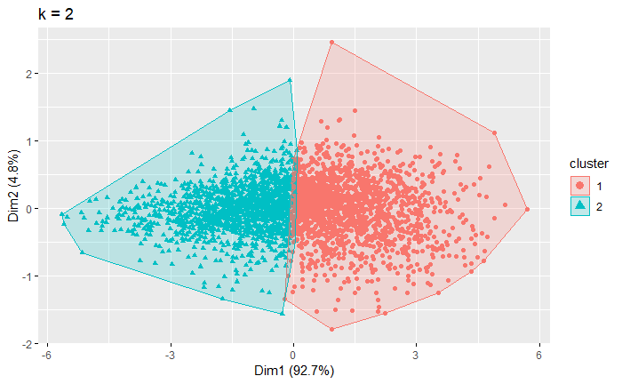

```r
########## Implementing kmeans model for filtered CB dataset
kmeans_CB <- kmeans(df_CBfiltered, centers = 2, nstart = 25)
### Creating the clustering plot for the model created-----
CB_plot <- fviz_cluster(kmeans_CB,data = df_CBfiltered,geom = "point") + ggtitle("k = 2")
CB_plot
```

4. The average or means for the variables or attributes in the different clusters

```r
CB_centers=as.data.frame(kmeans_CB$centers)
CB_centers
```

```
   Overall  Marking StandingTackle
1 71.72348 71.88544       73.54345
2 61.42714 59.59705       62.70279
```

5 ) Filtering CAM data

```r
#### Correlations between all numerical variables
Corr_CAM=data.frame(cor(df_CAM[,c(2,7:40)]))
#### First column shows correlation of different variables with the overall rating of the player
Corr_CAM[0:1,]
```

```
        Overall  Crossing Finishing HeadingAccuracy ShortPassing   Volleys Dribbling     Curve FKAccuracy LongPassing
Overall       1 0.8066785 0.8235516       0.3860968    0.8552414 0.7301713 0.9014583 0.7544769  0.6912967   0.7121225
        BallControl Acceleration SprintSpeed   Agility Reactions   Balance ShotPower   Jumping   Stamina  Strength
Overall    0.934478     0.436192   0.3693087 0.4960882 0.8347965 0.1971279 0.7243669 0.1233299 0.5395076 0.2978821
        LongShots Aggression Interceptions Positioning    Vision Penalties Composure    Marking StandingTackle
Overall 0.8102229  0.3149051     0.2648396   0.8579508 0.8856898 0.6388085 0.6984476 0.01057837      0.1059539
        SlidingTackle    GKDiving GKHandling   GKKicking GKPositioning GKReflexes
Overall   -0.02935594 -0.01425567 0.04595225 -0.01153441   -0.02822824 0.02085074
```

```r
####Creating a subset of data for the variables with correlation greater than 0.9
Corr_CAMMax=subset(Corr_CAM[0:1],Corr_CAM[1]>0.9)
Corr_CAMMax
```

```
              Overall
Overall     1.0000000
Dribbling   0.9014583
BallControl 0.9344780
```

6. New dataset CAM position, filtered

```r
### creating new subset for players with only 3 attributes for CAM
list=rownames(Corr_CAMMax)
df_CAMfiltered=df_CAM[,c(list)]
dim(df_CAMfiltered)
```

```
[1] 2042    3
```

7)k-means for clustering CAM

```r
############ Prediction strength for CAM position, cutoff=0.9, clusters 2 to 15--------
library(fpc)
prediction.strength(df_CAMfiltered, Gmin=2, Gmax=15, M=10,cutoff=0.9)
```

```
Prediction strength
Clustering method:  kmeans
Maximum number of clusters:  15
Resampled data sets:  10
Mean pred.str. for numbers of clusters:  1 0.8999116 0.8390857 0.7706075 0.6591913 0.6997691 0.5826059 0.4860163 0.4208055 0.4012008 0.3662079 0.340077 0.3361504 0.3368448 0.3107547
Cutoff value:  0.9
Largest number of clusters better than cutoff:  1
```

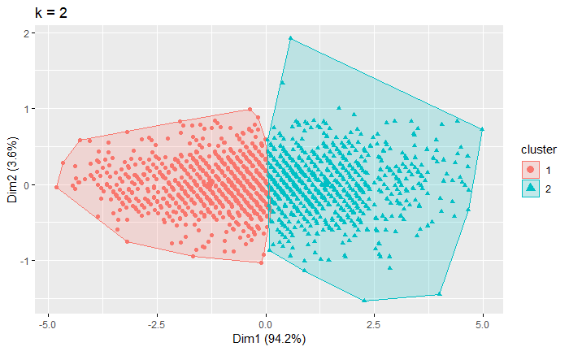

```r
######## Implementation of kmeans model for CAM position
library(factoextra)
kmeans_CAM <- kmeans(df_CAMfiltered, centers = 2, nstart = 25)
#####Plotting of the clusters created for CAM position
CAM_plot <- fviz_cluster(kmeans_CAM,data = df_CAMfiltered,geom = "point") + ggtitle("k = 2")
CAM_plot
```

8. The average or means for the variables or attributes in the different clusters for CAM position

```r
CAM_centers=as.data.frame(kmeans_CAM$centers)
CAM_centers
```

```
   Overall Dribbling BallControl
1 72.79183  75.55418    75.70722
2 61.26465  62.50505    63.12121
```

9. df_ST, filtering of ST position dataset

```r
#### Correlations between all numerical variables
Corr_ST=data.frame(cor(df_ST[,c(2,7:40)]))
#### First column shows correlation of different variables with the overall rating of the player
Corr_ST[0:1,]
```

```
        Overall  Crossing Finishing HeadingAccuracy ShortPassing   Volleys Dribbling    Curve FKAccuracy LongPassing
Overall       1 0.6137143 0.8934704       0.7293358    0.7926174 0.8177693 0.8100537 0.648961  0.5788586   0.5692712
        BallControl Acceleration SprintSpeed   Agility Reactions     Balance ShotPower   Jumping   Stamina  Strength
Overall   0.9040536    0.2329597    0.284852 0.3199748 0.8481355 0.005477097 0.8396196 0.3761896 0.4860211 0.4993974
        LongShots Aggression Interceptions Positioning    Vision Penalties Composure   Marking StandingTackle
Overall 0.7664006  0.5311679       0.37368   0.9003454 0.6633732 0.5767522 0.7545132 0.2035796      0.3196149
        SlidingTackle   GKDiving GKHandling  GKKicking GKPositioning GKReflexes
Overall     0.2318924 0.01592784 0.05853382 0.05274234    0.01290965 0.04739253
```

```r
####Creating a subset of data for the variables with correlation greater than 0.9
Corr_STMax=subset(Corr_ST[0:1],Corr_ST[1]>0.9)
Corr_STMax
```

```
              Overall
Overall     1.0000000
BallControl 0.9040536
Positioning 0.9003454
```

10. Filtering of ST Data to contain only 3 attributes

```r
### creating new subset for players with only 3 attributes for ST
list_ST=rownames(Corr_STMax)
df_STfiltered=df_ST[,c(list_ST)]
dim(df_STfiltered)
```

```
[1] 2594    3
```

11. Model implementation for ST position

```r
####### prediction strength for ST position for 2 to 15 clusters-----
library(fpc)
prediction.strength(df_STfiltered, Gmin=2, Gmax=15, M=10,cutoff=0.9)
```

```
Prediction strength
Clustering method:  kmeans
Maximum number of clusters:  15
Resampled data sets:  10
Mean pred.str. for numbers of clusters:  1 0.9235789 0.9061279 0.7553757 0.624536 0.524789 0.4674348 0.4217176 0.4264079 0.4099741 0.3670718 0.3728696 0.3526408 0.3372867 0.3412887
Cutoff value:  0.9
Largest number of clusters better than cutoff:  3
```

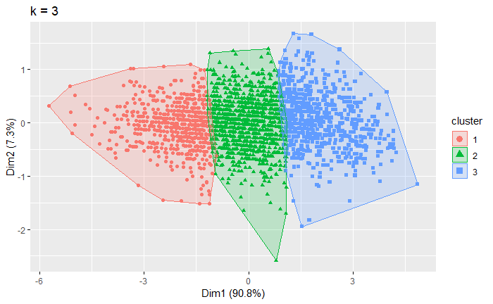

```r
######## Model implemetnation for best number of clusters
library(factoextra)
kmeans_ST <- kmeans(df_STfiltered, centers = 3, nstart = 25)
###### Plotting of created model
ST_plot <- fviz_cluster(kmeans_ST,data = df_STfiltered,geom = "point") + ggtitle("k = 3")
ST_plot
```

12. The average or means for the variables or attributes in the different clusters for ST position

```r
ST_centers=as.data.frame(kmeans_ST$centers)
ST_centers
```

```
   Overall BallControl Positioning
1 74.50077    73.41348    76.81011
2 66.11980    64.20782    65.97066
3 57.66246    54.65546    54.21289
```

13. df_GK filtering

```r
#### Correlations between all numerical variables
Corr_GK=data.frame(cor(df_GK[,c(2,7:40)]))
#### First column shows correlation of different variables with the overall rating of the player
Corr_GK[0:1,]
```

```
        Overall   Crossing Finishing HeadingAccuracy ShortPassing   Volleys Dribbling      Curve FKAccuracy LongPassing
Overall       1 0.03399797 0.1489334      0.03007539    0.2036872 0.1774129 0.1165511 0.05876509  0.1088647   0.2431758
        BallControl Acceleration SprintSpeed   Agility Reactions    Balance ShotPower   Jumping   Stamina  Strength
Overall   0.2329847     0.353765   0.3603213 0.3707419 0.8369417 0.03902657 0.1164627 0.4308624 0.2408098 0.3578076
        LongShots Aggression Interceptions Positioning   Vision Penalties Composure   Marking StandingTackle
Overall 0.1675454  0.2965902     0.2946703   0.2219909 0.403322 0.1838411 0.4392009 0.1248707    -0.02436847
        SlidingTackle  GKDiving GKHandling GKKicking GKPositioning GKReflexes
Overall  -0.009177389 0.9228201  0.9134378 0.7546616     0.9216754  0.9259375
```

```r
####Creating a subset of data for the variables with correlation greater than 0.9
Corr_GKMax=subset(Corr_GK[0:1],Corr_GK[1]>0.9)
Corr_GKMax
```

```
                Overall
Overall       1.0000000
GKDiving      0.9228201
GKHandling    0.9134378
GKPositioning 0.9216754
GKReflexes    0.9259375
```

14. GK data filtering to include only 5 attributes

```r
### creating new subset for players with only 5 attributes for GK
list_GK=rownames(Corr_GKMax)
df_GKfiltered=df_GK[,c(list_GK)]
dim(df_GKfiltered)
```

```
[1] 1994    5
```

15. Model implemenation for GK data

```r
######## prediction strength for 2 to 15 clusters, cutoff=0.9-------------
library(fpc)
prediction.strength(df_GKfiltered, Gmin=2, Gmax=15, M=10,cutoff=0.9)
```

```
Prediction strength
Clustering method:  kmeans
Maximum number of clusters:  15
Resampled data sets:  10
Mean pred.str. for numbers of clusters:  1 0.931333 0.7649994 0.7935753 0.6919574 0.5607238 0.469706 0.4374292 0.3981946 0.3774238 0.3520044 0.3414225 0.3351133 0.3112831 0.2924779
Cutoff value:  0.9
Largest number of clusters better than cutoff:  2
```

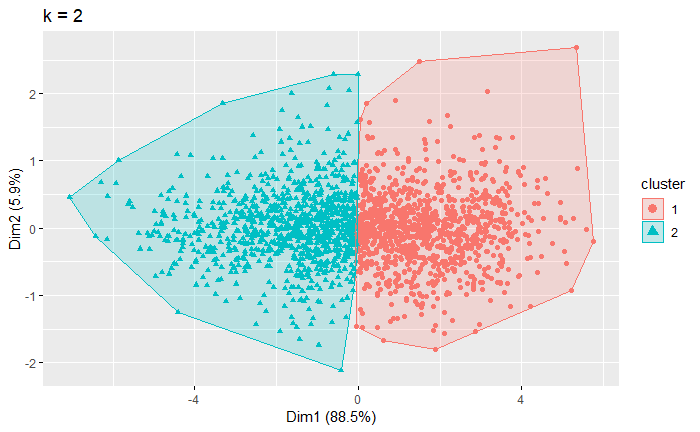

```r
####### Implementation of kmeans model for GK players
library(factoextra)
kmeans_GK <- kmeans(df_GKfiltered, centers = 2, nstart = 25)
####### Plotting of clusters for GK data
GK_plot <- fviz_cluster(kmeans_GK,data = df_GKfiltered,geom = "point") + ggtitle("k = 2")
GK_plot
```

16. The average or means for the variables or attributes in the different clusters for GK kmeans model

```r
GK_centers=as.data.frame(kmeans_GK$centers)
GK_centers
```

```
   Overall GKDiving GKHandling GKPositioning GKReflexes
1 58.39803 59.42660   56.41478      56.58916   59.67685
2 70.81512 71.25026   68.81716      69.64454   72.36261
```

———————————————————————————————————————————————————————————————————————————————————————————————————————————————————————————————————————————————————————————————————————————————————————————————————————————————————————————————————————————————————————————————————————————————————————————————————————————————————————————————————————————————————————————————————————————————————————————————————————————————————————————————————————————————————FINAL VALIDATION OF REGRESSION AND CLASSIFICATION MODELS————————————

1. Testing on outside regression data

```r
############ Extracting unused data from df_Final into df_validation
df_validation=df_Final[!(df_Final$Name %in% df_downsample$x.Name),]
############ Changing Best.Position attribute to match the downsampled data
df_validation$Best.Position=factor(df_validation$Best.Position,levels= c('GK','CB','CAM','ST'),
                          labels = c(1,2,3,4))
colnames(df_downsample)
```

```
 [1] "x.Name"            "x.Overall"         "x.Weak.Foot"       "x.Skill.Moves"     "x.Work.Rate"
 [6] "x.Body.Type"       "x.Crossing"        "x.Finishing"       "x.HeadingAccuracy" "x.ShortPassing"
[11] "x.Volleys"         "x.Dribbling"       "x.Curve"           "x.FKAccuracy"      "x.LongPassing"
[16] "x.BallControl"     "x.Acceleration"    "x.SprintSpeed"     "x.Agility"         "x.Reactions"
[21] "x.Balance"         "x.ShotPower"       "x.Jumping"         "x.Stamina"         "x.Strength"
[26] "x.LongShots"       "x.Aggression"      "x.Interceptions"   "x.Positioning"     "x.Vision"
[31] "x.Penalties"       "x.Composure"       "x.Marking"         "x.StandingTackle"  "x.SlidingTackle"
[36] "x.GKDiving"        "x.GKHandling"      "x.GKKicking"       "x.GKPositioning"   "x.GKReflexes"
[41] "y"
```

```r
colnames(df_validation)<-colnames(df_downsample)
########### XGB model regression validation
predictValidation_XGB = predict(XGB_model, newdata = df_validation[,c(7:41)])
RMSE(predictValidation_XGB,df_validation$x.Overall)
```

```
[1] 1.424597
```

```r
mape(predictValidation_XGB,df_validation$x.Overall)
```

```
[1] 0.0166483
```

```r
########### GBM model regression validation
predictValidation_GBM = predict(GBM_model, newdata = df_validation[,c(7:41)])
RMSE(predictValidation_GBM,df_validation$x.Overall)
```

```
[1] 1.694191
```

```r
mape(predictValidation_GBM,df_validation$x.Overall)
```

```
[1] 0.01986852
```

```r
############ Bagged mdodel regression validation
predictValidation_bag = predict(bag_model, newdata = df_validation[,c(7:41)])
RMSE(predictValidation_bag,df_validation$x.Overall)
```

```
[1] 1.603964
```

```r
mape(predictValidation_bag,df_validation$x.Overall)
```

```
[1] 0.0178663
```

2. Testing classification on outside data

```r
############SVM validation-----
predictValidation_SVM = predict(opt_model, newdata = df_validation[,c(2,7:40)])
confusionMatrix(df_validation$y,predictValidation_SVM)
```

```
Confusion Matrix and Statistics

          Reference
Prediction    1    2    3    4
         1   43    0    0    2
         2    9 1555    0    2
         3    0    0    0    0
         4    6    0    0  555

Overall Statistics

               Accuracy : 0.9913
                 95% CI : (0.9864, 0.9947)
    No Information Rate : 0.7159
    P-Value [Acc > NIR] : < 2.2e-16

                  Kappa : 0.979
 Mcnemar's Test P-Value : NA

Statistics by Class:

                     Class: 1 Class: 2 Class: 3 Class: 4
Sensitivity           0.74138   1.0000       NA   0.9928
Specificity           0.99905   0.9822        1   0.9963
Pos Pred Value        0.95556   0.9930       NA   0.9893
Neg Pred Value        0.99295   1.0000       NA   0.9975
Prevalence            0.02670   0.7159        0   0.2574
Detection Rate        0.01980   0.7159        0   0.2555
Detection Prevalence  0.02072   0.7210        0   0.2583
Balanced Accuracy     0.87022   0.9911       NA   0.9946
```

```r
########### RF validation
predictValidation_RF = predict(model_rf, newdata = df_validation[,c(2,7:40)])
#######Convert target classification variable to match the built RF model
df_validationRF=df_validation
df_validationRF$y = factor(df_validationRF$y,labels= c('GK','CB','CAM','ST'),
                          levels = c(1,2,3,4))
confusionMatrix(df_validationRF$y,predictValidation_RF)
```

```
Confusion Matrix and Statistics

          Reference
Prediction   GK   CB  CAM   ST
       GK    43    1    0    1
       CB     8 1558    0    0
       CAM    0    0    0    0
       ST    16    3    0  542

Overall Statistics

               Accuracy : 0.9866
                 95% CI : (0.9809, 0.991)
    No Information Rate : 0.7192
    P-Value [Acc > NIR] : < 2.2e-16

                  Kappa : 0.9679
 Mcnemar's Test P-Value : NA

Statistics by Class:

                     Class: GK Class: CB Class: CAM Class: ST
Sensitivity            0.64179    0.9974         NA    0.9982
Specificity            0.99905    0.9869          1    0.9883
Pos Pred Value         0.95556    0.9949         NA    0.9661
Neg Pred Value         0.98872    0.9934         NA    0.9994
Prevalence             0.03085    0.7192          0    0.2500
Detection Rate         0.01980    0.7173          0    0.2495
Detection Prevalence   0.02072    0.7210          0    0.2583
Balanced Accuracy      0.82042    0.9922         NA    0.9932
```